# assignment

Marco Fiorani Borraccino

2026-03-25

```r
setwd("~/Desktop/ethEpigen2026_material/week05")
suppressPackageStartupMessages({
  library(GenomicRanges)
  library(SummarizedExperiment)
  library(edgeR) # differential gene expression using neg.bin stats
  library(epiwraps)
  library(ggplot2)
  library(sechm) # for plotting (features*samples) heatmaps
  library(epiwraps)
  library(magick)
})
```

### Download (a subset of) ATAC-seq peak counts in the hippocampus upon stress (already in SummarizedExperiment format): 20,660 Rows and 12 samples

```r
download.file(
  url = "https://ethz-ins.org/content/mouse_mm38_hippocampus.peakCounts.SE.rds",
  destfile = "mouse_hippocampus.rds"
) #from mouse ensembl GRCm38 genome
se <- readRDS("mouse_hippocampus.rds")
#colnames(se)
#rownames(se)

#Add ranges coordinates to rownames of se
coords <- paste0(seqnames(se), ":", start(se), "-", end(se))
#Assign those coordinate strings as the official rownames of your object
rownames(se) <- coords
```

### TMM normalization

```r
#IF colname has FSS call it FSS otherwise Control:
groups<- ifelse(grepl("FSS", colnames(se)), "FSS", "Control")
#Add this vector into the se object's colData
se$condition <- groups
# we first put the data in the object structure edgeR uses:
dds <- edgeR::DGEList(assay(se), group=groups)
# we normalize, by default using TMM normalization:
dds <- edgeR::calcNormFactors(dds)
# we estimate dispersions:
dds <- edgeR::estimateDisp(dds)
```

```
## Using classic mode.
```

```r
#exactTest(dds): compares the two groups (e.g., FSS vs. Control) and calculates the P-value and logFC for all 20,660 peaks.
et <- as.data.frame(topTags(exactTest(dds), Inf, sort.by="PValue")) # or sort.by="logFC" if you want to sort them / PValue
#head(et) debug
#rowRanges(se)[15757, ] debug
```

## 1. Comparing stressed (denoted ‘FSS’ – forced swim stress) and control animals

### Plotting the top20 most significant differentially regions

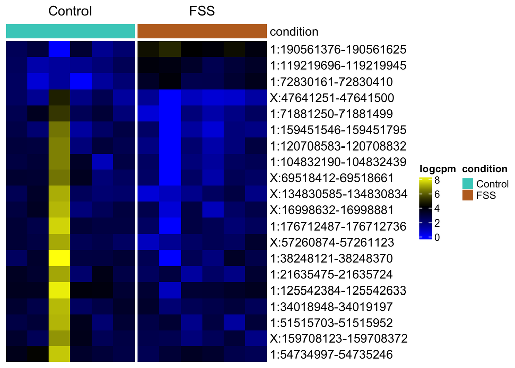

```r
# we first place the normalized data back into our original SummarizedExperiment object:
assay(se, "logcpm") <- log1p(cpm(dds)) #withDimnames = FALSE will not consider rownames generated by cmp(dds) and just use the position since "se" doesn't have rownames
# we then plot the 20 most significant regions:
topRegions <- head(row.names(et),20)
sechm(se, topRegions, gaps_at="condition")
```

#### It seems like there is an outlier sample (Control_female_GSM6041843). In class we haven’t discussed yet how to manage it, but the Prof on slack/questions (25.03.2026) said to leave it as it is for this task.

### Looking at how many significant diff. regions there are

```
##                           logFC   logCPM       PValue        FDR
## 1:190561376-190561625  2.956602 5.568769 2.042974e-06 0.04220785
## 1:176712487-176712736 -5.547326 7.661587 3.527416e-05 0.12814460
## X:134830585-134830834 -5.303580 6.889311 4.895397e-05 0.12814460
## 1:125542384-125542633 -4.828255 8.216940 5.221790e-05 0.12814460
## 1:38248121-38248370   -5.984659 8.519979 5.504660e-05 0.12814460
## 1:72830161-72830410    2.858099 4.136854 5.892303e-05 0.12814460
```

```
## Significant regions with FDR < 0.05:  1
```

#### There is only 1 single region (1:190561376-190561625, FDR = 0.04) with FDR < 0.05 between FSS and Control group. This suggest that forced swim stress do not induce any significant change in the accessible chromatin of mice. Out of curiosity, I watched at that only significant region, hoping to have discovered a “forced swim stress gene” but I’ve ended up in a “desert”. In that region, attached screen from UCSC genome browser, there is neither one transcript or enhancer element. This suggest that even this one region could just be a false positive and the difference in ATAC-seq technical noise.

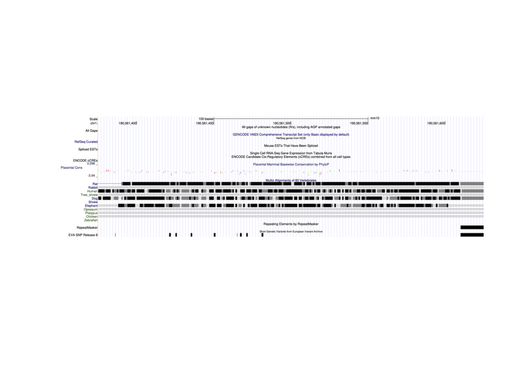

```r
plot(img)
```

## 2. Comparing male and female animals (using similar pipeline as above)

### 2.1 Comparing ctrl_male vs ctrl_female

```r
#filter "se" obj taking only control samples
se_ctrl <- se[, se$condition == "Control"]
#filter male and female
sex_groups <- ifelse(grepl("Female", colnames(se_ctrl), ignore.case = TRUE), "Female", "Male")
se_ctrl$sex <- factor(sex_groups, levels = c("Female", "Male"))
# TMM normalization - same process as before with different groups
dds <- edgeR::DGEList(assay(se_ctrl), group=se_ctrl$sex)
dds <- edgeR::calcNormFactors(dds)
dds <- edgeR::estimateDisp(dds)
```

```
## Using classic mode.
```

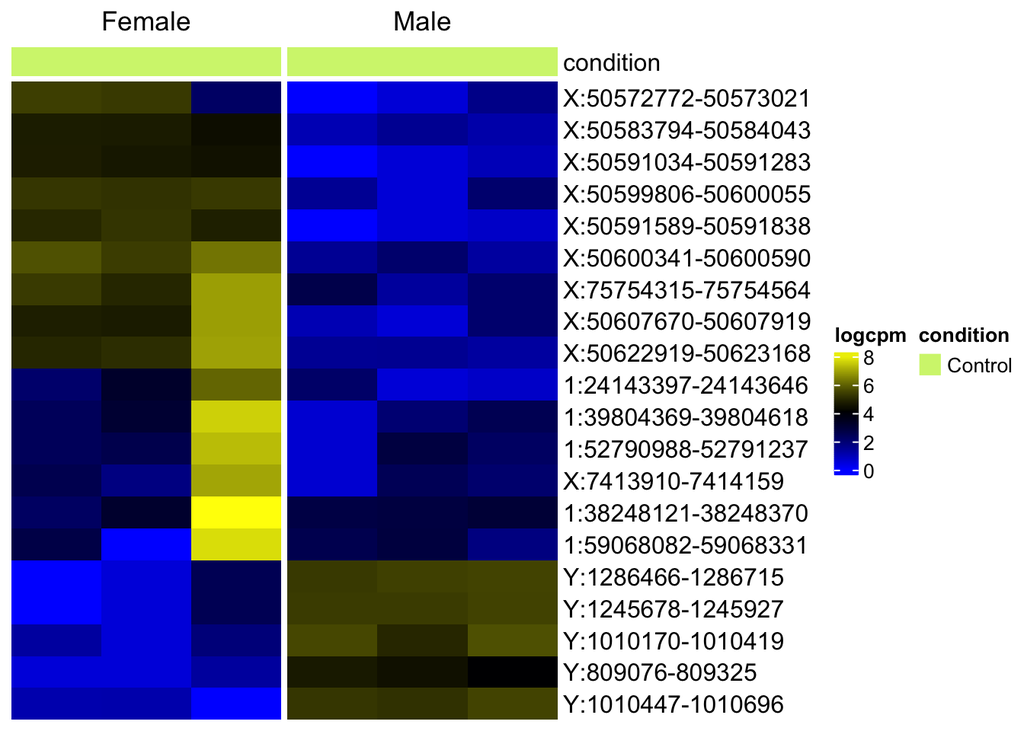

```r
et <- as.data.frame(topTags(exactTest(dds), Inf, sort.by="PValue"))
#Plotting with sechm
assay(se_ctrl, "logcpm") <- log1p(cpm(dds))
topRegions <- head(row.names(et),20)
sechm(se_ctrl, topRegions, gaps_at="sex")
```

```r
#how many significant different regions there are between male and female
tot_sig <- sum(et$FDR < 0.05)
et_autosome_sig <- et[!(grepl("^X:", row.names(et)) | grepl("^Y:", row.names(et))) & et$FDR < 0.05, ] #Filter: NO X, NO Y and FDR < 0.05
tot_autosome_sig <- nrow(et_autosome_sig)
cat("Total significant regions (including X/Y):", tot_sig, "\n")
```

```
## Total significant regions (including X/Y): 190
```

```r
cat("Significant autosomal regions (excluding X/Y):", tot_autosome_sig, "\n")
```

```
## Significant autosomal regions (excluding X/Y): 108
```

#### It is noticeable that the most significant regions to be different between control males and females are the ones from the sex chromosomes (roughly 50% of all), and this makes sense. Females has double X-chr and even if one is inactivated, some regions could still be open and detected twice by ATAC-seq. The males, instead, have only one X and they are the only ones to have the Y-chr so we should notice that open regions on the Y must be present only in males, but there are also in females. why ? explanation at the end*

## Comparing Ctrl vs FSS by male and female

```r
#Create sex groups based on column names
sex_groups <- ifelse(grepl("Female", colnames(se), ignore.case = TRUE), "Female", "Male")
se$sex <- factor(sex_groups)
#Feed the new groups into edgeR
dds_sex <- edgeR::DGEList(assay(se), group = se$sex)
#Run the same pipeline
dds_sex <- edgeR::calcNormFactors(dds_sex)
dds_sex <- edgeR::estimateDisp(dds_sex)
```

```
## Using classic mode.
```

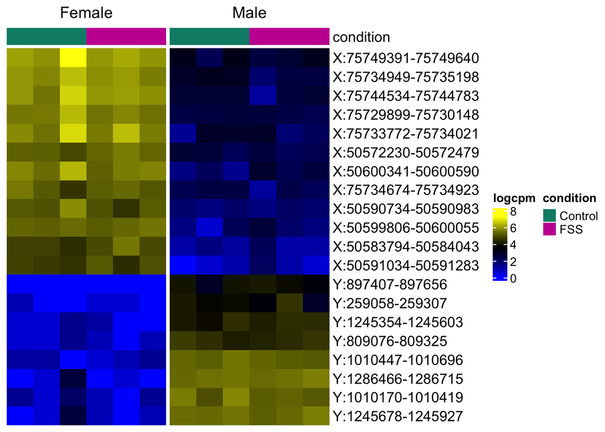

```r
et_sex <- as.data.frame(topTags(exactTest(dds_sex), Inf, sort.by="PValue"))
#Plot using the "sex" column for gaps
assay(se, "logcpm") <- log1p(cpm(dds_sex))
topRegions_sex <- head(row.names(et_sex), 20)
sechm(se, topRegions_sex, gaps_at="sex")
```

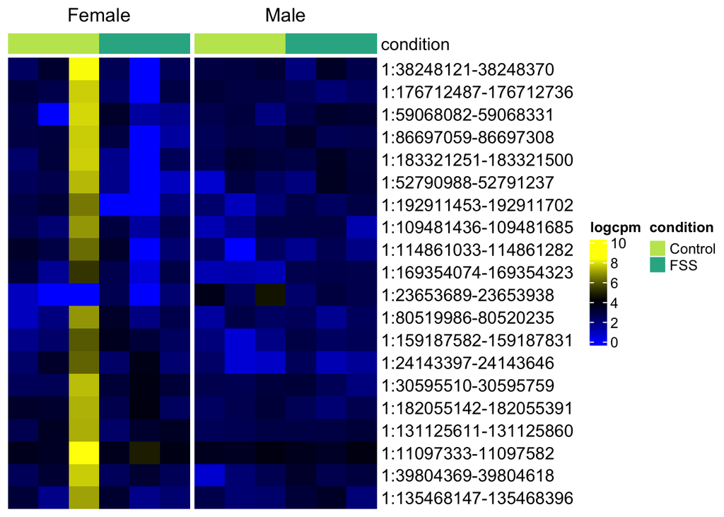

```r
#Filter out the X-Y chr that could shadow the real differences caused by the FSS and not by the sex
#Filter: NO X, NO Y and FDR < 0.05
et_autosome_sig <- et[!(grepl("^X:", row.names(et)) | grepl("^Y:", row.names(et))) & et$FDR < 0.05, ]
top_autosome_sig <- head(row.names(et_autosome_sig), 20)
sechm(se, top_autosome_sig, gaps_at="sex")
```

#### Again, we don’t see any significant differences between the Ctrl and FSS group in only males or females. Sex differences (X-Y-chr regions) stands out more than differences in FSS-ctrl and even avoiding/filtering out X-Y-chr it’s still not possible to see differences between FSS and ctrl group (except for the same outlier in ctrl_female)

#### In conclusion there are no differences in FSS vs Ctrl group, even with sex specific analysis.

### EXTRA*: Why Y-chr open regions appear on female samples, with raw counts > 0 and rarely “high count” ? (all significant ones are plotted)

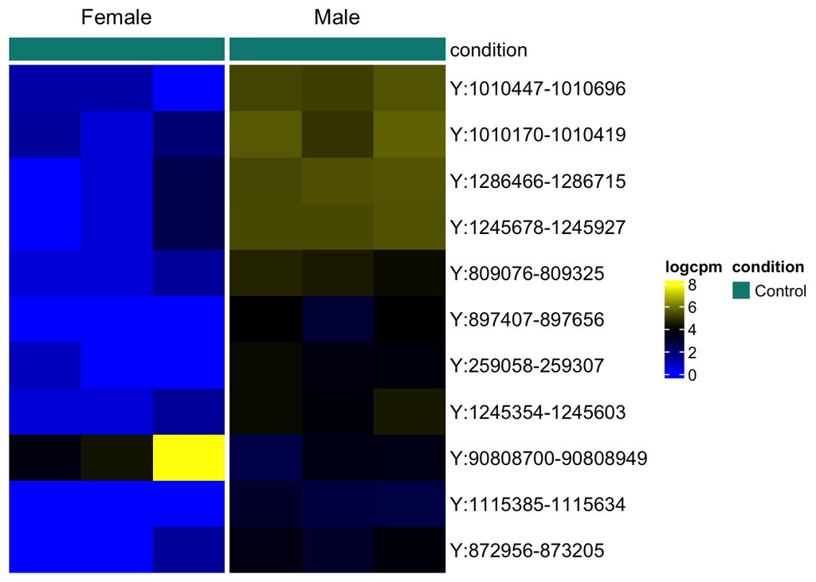

```r
#Filter Y-chr regions and significants (they are 11 in total, so i'll plot all)
et_Y_sig <- et[grepl("^Y:", row.names(et)) & et$FDR < 0.05, ]

topRegions_Y_sig <- row.names(et_Y_sig)

sechm(se_ctrl, topRegions_Y_sig,
      gaps_at = "sex",
      assayName = "logcpm",
      show_rownames = TRUE, cluster_rows = FALSE,)
```

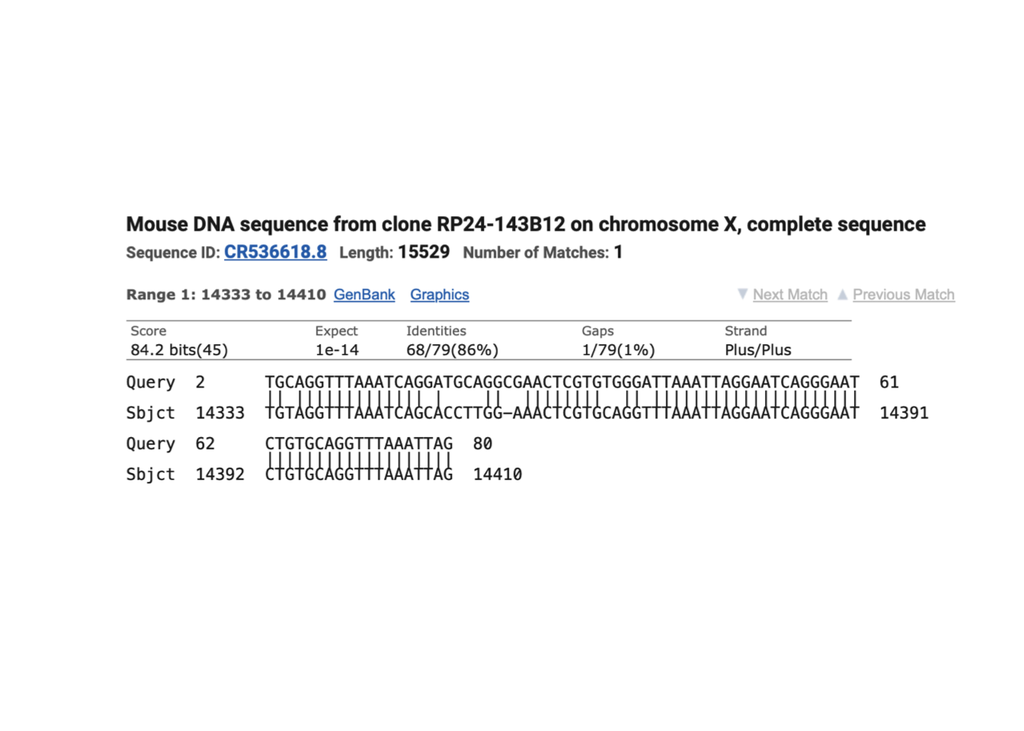

```r
#blastn
img <- image_read("homology_Y_X.png")
plot(img)
```

#### We can observe that the logCPM of Y-chr region on females are not light blu (=0) and one of them is shockingly high.

#### I think this is because of an error from the allignment software. During the allignment (by default on a male reference genome, so XY) the software could mistakenly align a read to the wrong genomic region if there are similar/high-homology regions on different chromosomes. Indeed X and Y have similar regions with high homology and this could confuse the software, that could “in some extent” align the read to both.

#### In order to verify this idea, I look at FASTA sequence of the yellow region in one female sample Y:90808700-90808949 and search with blastn if there were a similar one in the X-chr and I found a region with 86% of homology (I’ll attach screenshot). So it’s possible that the read on the X-chr is being mis-aligned to the Y-chr.

#### In order to be sure about it, I should compare the reads aligned in both regions X/Y-homologs in many samples and see if in that sample, the reads have been aligned more in the Y-chr. (But I’m sorry, I didn’t check further)